# Introduction to Deep Learning

## Part 4: Check output

Let’s return to our original model using the vectorized data:

### Metrics

```r
metrics <- network %>% evaluate(test_data, test_targets)
```

```r
metrics
```

```
## $loss
## [1] 0.9191864
##
## $acc
## [1] 0.6960784
```

The accuracy is 0.6960784 and the error rate, i.e. incorrect calling, is 0.3039216.

### Predictions

```r
network %>% predict_classes(test_data[1:10,])
```

```
##  [1] 0 1 2 2 2 2 3 2 1 2
```

```r
predictions <- network %>% predict_classes(test_data)
actual <- unlist(test_targets)
totalmisses <- sum(predictions != actual)
```

### Confusion Matrix

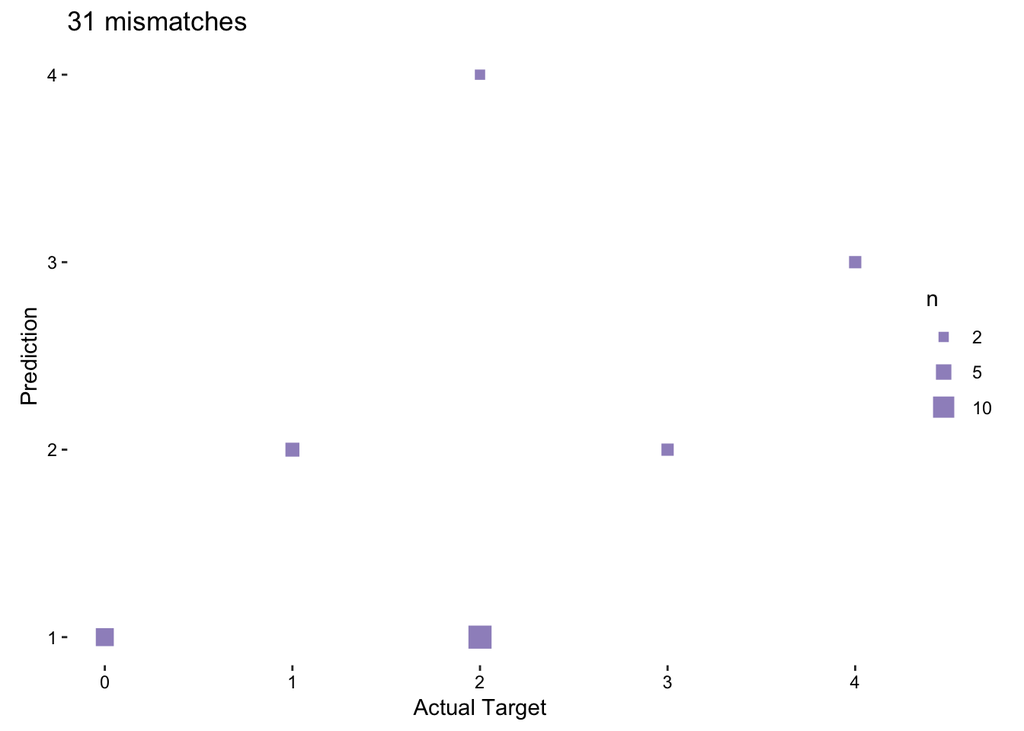

## Vectorization

For softmax, we get the probabilities for each class. For this purpose you’ll often see `categorical_crossentropy` as a loss function. To use this, the targets/labels need to be in the same format. We can achieve this using:

```r
head(train_targets)
```

```
## [1] 1 4 4 2 1 1
```

```r
train_targets_vec <- to_categorical(train_targets)
test_targets_vec <- to_categorical(test_targets)

head(train_targets_vec)
```

```
##      [,1] [,2] [,3] [,4] [,5]
## [1,]    0    1    0    0    0
## [2,]    0    0    0    0    1
## [3,]    0    0    0    0    1
## [4,]    0    0    1    0    0
## [5,]    0    1    0    0    0
## [6,]    0    1    0    0    0
```